# Object detection as in SSD (basic principles)

```r
library(keras)
library(rjson)
library(magick)
library(purrr)
library(tibble)
library(tidyr)
library(dplyr)
library(ggplot2)
library(stringr)

use_session_with_seed(7777, disable_gpu = FALSE, disable_parallel_cpu = FALSE)
```

```
Set session seed to 7777
```

We start with the same preprocessing steps as before - but we don’t need to zoom in on the most salient object any more.

Here again are the basic preprocessing steps.

# Data loading / preprocessing (same as in previous notebook)

## Dataset

```r
img_dir <- "data/VOCdevkit/VOC2007/JPEGImages"
```

```r
annot_file <- "data/pascal_train2007.json"
```

## Preprocessing

```r
load_and_preprocess_image <- function(image_name, target_height, target_width) {
  img_array <- image_load(
    file.path(img_dir, image_name),
    target_size = c(target_height, target_width)
    ) %>%
    image_to_array() %>%
    xception_preprocess_input()
  dim(img_array) <- c(1, dim(img_array))
  img_array
}
```

```r
annotations <- fromJSON(file = annot_file)
str(annotations, max.level = 1)
```

```
List of 4
 $ images     :List of 2501
 $ type       : chr "instances"
 $ annotations:List of 7844
 $ categories :List of 20
```

```r
imageinfo <- annotations$images %>% {
  tibble(
    id = map_dbl(., "id"),
    file_name = map_chr(., "file_name"),
    image_height = map_dbl(., "height"),
    image_width = map_dbl(., "width")
  )
}
imageinfo
```

| id | file_name | image_height | image_width |
| --- | --- | --- | --- |
| 12 | 000012.jpg | 333 | 500 |
| 17 | 000017.jpg | 364 | 480 |
| 23 | 000023.jpg | 500 | 334 |
| 26 | 000026.jpg | 333 | 500 |
| 32 | 000032.jpg | 281 | 500 |
| 33 | 000033.jpg | 366 | 500 |
| 34 | 000034.jpg | 500 | 360 |
| 35 | 000035.jpg | 375 | 500 |
| 36 | 000036.jpg | 500 | 332 |
| 42 | 000042.jpg | 335 | 500 |

[output cut: 990 more lines]

```r
boxinfo <- annotations$annotations %>% {
  tibble(
    image_id = map_dbl(., "image_id"),
    category_id = map_dbl(., "category_id"),
    bbox = map(., "bbox")
  )
}
boxinfo
```

| image_id | category_id | bbox |
| --- | --- | --- |
| 12 | 7 |  |
| 17 | 15 |  |
| 17 | 13 |  |
| 23 | 2 |  |
| 23 | 2 |  |
| 23 | 2 |  |
| 23 | 15 |  |
| 23 | 15 |  |
| 23 | 15 |  |
| 26 | 7 |  |

[output cut: 990 more lines]

```r
boxinfo <- boxinfo %>%
  mutate(bbox = unlist(map(.$bbox, function(x) paste(x, collapse = " "))))
boxinfo <- boxinfo %>%
  separate(bbox, into = c("x_left", "y_top", "bbox_width", "bbox_height"))
boxinfo <- boxinfo %>% mutate_all(as.numeric)
boxinfo
```

| image_id | category_id | x_left | y_top | bbox_width | bbox_height |
| --- | --- | --- | --- | --- | --- |
| 12 | 7 | 155 | 96 | 196 | 174 |
| 17 | 15 | 184 | 61 | 95 | 138 |
| 17 | 13 | 89 | 77 | 314 | 259 |
| 23 | 2 | 8 | 229 | 237 | 271 |
| 23 | 2 | 229 | 219 | 105 | 281 |
| 23 | 2 | 1 | 177 | 89 | 323 |
| 23 | 15 | 1 | 0 | 116 | 369 |
| 23 | 15 | 2 | 1 | 241 | 461 |
| 23 | 15 | 224 | 0 | 110 | 486 |
| 26 | 7 | 89 | 124 | 248 | 88 |

[output cut: 990 more lines]

```r
boxinfo <- boxinfo %>%
  mutate(y_bottom = y_top + bbox_height - 1, x_right = x_left + bbox_width - 1)
boxinfo
```

| image_id | category_id | x_left | y_top | bbox_width | bbox_height | y_bottom | x_right |
| --- | --- | --- | --- | --- | --- | --- | --- |
| 12 | 7 | 155 | 96 | 196 | 174 | 269 | 350 |
| 17 | 15 | 184 | 61 | 95 | 138 | 198 | 278 |
| 17 | 13 | 89 | 77 | 314 | 259 | 335 | 402 |
| 23 | 2 | 8 | 229 | 237 | 271 | 499 | 244 |
| 23 | 2 | 229 | 219 | 105 | 281 | 499 | 333 |
| 23 | 2 | 1 | 177 | 89 | 323 | 499 | 89 |
| 23 | 15 | 1 | 0 | 116 | 369 | 368 | 116 |
| 23 | 15 | 2 | 1 | 241 | 461 | 461 | 242 |
| 23 | 15 | 224 | 0 | 110 | 486 | 485 | 333 |
| 26 | 7 | 89 | 124 | 248 | 88 | 211 | 336 |

[output cut: 990 more lines]

```r
catinfo <- annotations$categories %>%  {
  tibble(id = map_dbl(., "id"), name = map_chr(., "name"))
}
catinfo
```

| id | name |
| --- | --- |
| 1 | aeroplane |
| 2 | bicycle |
| 3 | bird |
| 4 | boat |
| 5 | bottle |
| 6 | bus |
| 7 | car |
| 8 | cat |
| 9 | chair |
| 10 | cow |

[output cut: 10 more lines]

```r
classes <- catinfo$name
```

```r
imageinfo <- imageinfo %>%
  inner_join(boxinfo, by = c("id" = "image_id")) %>%
  inner_join(catinfo, by = c("category_id" = "id"))
imageinfo
```

| id | file_name | image_height | image_width | category_id | x_left | y_top | bbox_width | bbox_height | y_bottom | x_right | name |
| --- | --- | --- | --- | --- | --- | --- | --- | --- | --- | --- | --- |
| 12 | 000012.jpg | 333 | 500 | 7 | 155 | 96 | 196 | 174 | 269 | 350 | car |
| 17 | 000017.jpg | 364 | 480 | 15 | 184 | 61 | 95 | 138 | 198 | 278 | person |
| 17 | 000017.jpg | 364 | 480 | 13 | 89 | 77 | 314 | 259 | 335 | 402 | horse |
| 23 | 000023.jpg | 500 | 334 | 2 | 8 | 229 | 237 | 271 | 499 | 244 | bicycle |
| 23 | 000023.jpg | 500 | 334 | 2 | 229 | 219 | 105 | 281 | 499 | 333 | bicycle |
| 23 | 000023.jpg | 500 | 334 | 2 | 1 | 177 | 89 | 323 | 499 | 89 | bicycle |
| 23 | 000023.jpg | 500 | 334 | 15 | 1 | 0 | 116 | 369 | 368 | 116 | person |
| 23 | 000023.jpg | 500 | 334 | 15 | 2 | 1 | 241 | 461 | 461 | 242 | person |
| 23 | 000023.jpg | 500 | 334 | 15 | 224 | 0 | 110 | 486 | 485 | 333 | person |
| 26 | 000026.jpg | 333 | 500 | 7 | 89 | 124 | 248 | 88 | 211 | 336 | car |

[output cut: 990 more lines]

```r
target_height <- 224
target_width <- 224

imageinfo <- imageinfo %>% mutate(
  x_left_scaled = (x_left / image_width * target_width) %>% round(),
  x_right_scaled = (x_right / image_width * target_width) %>% round(),
  y_top_scaled = (y_top / image_height * target_height) %>% round(),
  y_bottom_scaled = (y_bottom / image_height * target_height) %>% round(),
  bbox_width_scaled =  (bbox_width / image_width * target_width) %>% round(),
  bbox_height_scaled = (bbox_height / image_height * target_height) %>% round()
)
imageinfo
```

| id | file_name | image_height | image_width | category_id | x_left | y_top | bbox_width | bbox_height | y_bottom | x_right | name | x_left_scaled | x_right_scaled | y_top_scaled | y_bottom_scaled | bbox_width_scaled | bbox_height_scaled |
| --- | --- | --- | --- | --- | --- | --- | --- | --- | --- | --- | --- | --- | --- | --- | --- | --- | --- |
| 12 | 000012.jpg | 333 | 500 | 7 | 155 | 96 | 196 | 174 | 269 | 350 | car | 69 | 157 | 65 | 181 | 88 | 117 |
| 17 | 000017.jpg | 364 | 480 | 15 | 184 | 61 | 95 | 138 | 198 | 278 | person | 86 | 130 | 38 | 122 | 44 | 85 |
| 17 | 000017.jpg | 364 | 480 | 13 | 89 | 77 | 314 | 259 | 335 | 402 | horse | 42 | 188 | 47 | 206 | 147 | 159 |
| 23 | 000023.jpg | 500 | 334 | 2 | 8 | 229 | 237 | 271 | 499 | 244 | bicycle | 5 | 164 | 103 | 224 | 159 | 121 |
| 23 | 000023.jpg | 500 | 334 | 2 | 229 | 219 | 105 | 281 | 499 | 333 | bicycle | 154 | 223 | 98 | 224 | 70 | 126 |
| 23 | 000023.jpg | 500 | 334 | 2 | 1 | 177 | 89 | 323 | 499 | 89 | bicycle | 1 | 60 | 79 | 224 | 60 | 145 |
| 23 | 000023.jpg | 500 | 334 | 15 | 1 | 0 | 116 | 369 | 368 | 116 | person | 1 | 78 | 0 | 165 | 78 | 165 |
| 23 | 000023.jpg | 500 | 334 | 15 | 2 | 1 | 241 | 461 | 461 | 242 | person | 1 | 162 | 0 | 207 | 162 | 207 |
| 23 | 000023.jpg | 500 | 334 | 15 | 224 | 0 | 110 | 486 | 485 | 333 | person | 150 | 223 | 0 | 217 | 74 | 218 |
| 26 | 000026.jpg | 333 | 500 | 7 | 89 | 124 | 248 | 88 | 211 | 336 | car | 40 | 151 | 83 | 142 | 111 | 59 |

[output cut: 990 more lines]

# A model for object detection

For reference, let’s look at what we did to classify and localize one single object.

```r
feature_extractor <- application_xception(
  include_top = FALSE,
  input_shape = c(224, 224, 3)
)

input <- feature_extractor$input
common <- feature_extractor$output %>%
  layer_flatten(name = "flatten") %>%
  layer_activation_relu() %>%
  layer_dropout(rate = 0.25) %>%
  layer_dense(units = 512, activation = "relu") %>%
  layer_batch_normalization() %>%
  layer_dropout(rate = 0.5)

regression_output <-
  layer_dense(common, units = 4, name = "regression_output")
class_output <- layer_dense(
  common,
  units = 20,
  activation = "softmax",
  name = "class_output"
)

model <- keras_model(
  inputs = input,
  outputs = list(regression_output, class_output)
)
```

We again start with Xception as the feature extractor.

```r
feature_extractor <- application_xception(
  include_top = FALSE,
  input_shape = c(224, 224, 3)
)
feature_extractor
```

```
Model
__________________________________________________________________________________________________
Layer (type)                    Output Shape         Param #     Connected to
==================================================================================================
input_1 (InputLayer)            (None, 224, 224, 3)  0
__________________________________________________________________________________________________
block1_conv1 (Conv2D)           (None, 111, 111, 32) 864         input_1[0][0]
__________________________________________________________________________________________________
block1_conv1_bn (BatchNormaliza (None, 111, 111, 32) 128         block1_conv1[0][0]
__________________________________________________________________________________________________
block1_conv1_act (Activation)   (None, 111, 111, 32) 0           block1_conv1_bn[0][0]
__________________________________________________________________________________________________
block1_conv2 (Conv2D)           (None, 109, 109, 64) 18432       block1_conv1_act[0][0]
__________________________________________________________________________________________________
block1_conv2_bn (BatchNormaliza (None, 109, 109, 64) 256         block1_conv2[0][0]
__________________________________________________________________________________________________
block1_conv2_act (Activation)   (None, 109, 109, 64) 0           block1_conv2_bn[0][0]
__________________________________________________________________________________________________
block2_sepconv1 (SeparableConv2 (None, 109, 109, 128 8768        block1_conv2_act[0][0]
__________________________________________________________________________________________________
block2_sepconv1_bn (BatchNormal (None, 109, 109, 128 512         block2_sepconv1[0][0]
__________________________________________________________________________________________________
block2_sepconv2_act (Activation (None, 109, 109, 128 0           block2_sepconv1_bn[0][0]
__________________________________________________________________________________________________
block2_sepconv2 (SeparableConv2 (None, 109, 109, 128 17536       block2_sepconv2_act[0][0]
__________________________________________________________________________________________________
block2_sepconv2_bn (BatchNormal (None, 109, 109, 128 512         block2_sepconv2[0][0]
__________________________________________________________________________________________________
conv2d_1 (Conv2D)               (None, 55, 55, 128)  8192        block1_conv2_act[0][0]
__________________________________________________________________________________________________
block2_pool (MaxPooling2D)      (None, 55, 55, 128)  0           block2_sepconv2_bn[0][0]
__________________________________________________________________________________________________
batch_normalization_1 (BatchNor (None, 55, 55, 128)  512         conv2d_1[0][0]
__________________________________________________________________________________________________
add_1 (Add)                     (None, 55, 55, 128)  0           block2_pool[0][0]
                                                                 batch_normalization_1[0][0]
__________________________________________________________________________________________________
block3_sepconv1_act (Activation (None, 55, 55, 128)  0           add_1[0][0]
__________________________________________________________________________________________________
block3_sepconv1 (SeparableConv2 (None, 55, 55, 256)  33920       block3_sepconv1_act[0][0]
```

[output cut: 229 more lines]

```
__________________________________________________________________________________________________
block14_sepconv1_bn (BatchNorma (None, 7, 7, 1536)   6144        block14_sepconv1[0][0]
__________________________________________________________________________________________________
block14_sepconv1_act (Activatio (None, 7, 7, 1536)   0           block14_sepconv1_bn[0][0]
__________________________________________________________________________________________________
block14_sepconv2 (SeparableConv (None, 7, 7, 2048)   3159552     block14_sepconv1_act[0][0]
__________________________________________________________________________________________________
block14_sepconv2_bn (BatchNorma (None, 7, 7, 2048)   8192        block14_sepconv2[0][0]
__________________________________________________________________________________________________
block14_sepconv2_act (Activatio (None, 7, 7, 2048)   0           block14_sepconv2_bn[0][0]
==================================================================================================
Total params: 20,861,480
Trainable params: 20,806,952
Non-trainable params: 54,528
__________________________________________________________________________________________________
```

At this point, we have an output of 7x7x2048.

To arrive at the 4x4 grid cells we want, we apply a convolution with strides 2.

```r
input <- feature_extractor$input

common <- feature_extractor$output %>%
  layer_conv_2d(
    filters = 256,
    kernel_size = 3,
    padding = "same",
    name = "head_conv1"
  ) %>%
  layer_batch_normalization() %>%
  layer_conv_2d(
    filters = 256,
    kernel_size = 3,
    strides = 2,
    padding = "same",
    name = "head_conv2"
  ) %>%
  layer_batch_normalization()

common
```

```
Tensor("batch_normalization_6/cond/Merge:0", shape=(?, 4, 4, 256), dtype=float32)
```

Now we can do as we did before, attach an output for the bounding boxes and one for the classes.

Note how we don’t aggregate over the spatial grid though. Instead, we reshape it so the 4x4 grid cells appear sequentially (`layer_reshape`).

Here first is the class output. We have 21 classes now (the 20 classes from PASCAL, plus background), and we need to classify each cell. So we need an output of dimensions 16x21.

```r
class_output <-
  layer_conv_2d(
    common,
    filters = 21,
    kernel_size = 3,
    padding = "same",
    name = "class_conv"
  ) %>%
  layer_reshape(target_shape = c(16, 21), name = "class_flatten")
```

For the bounding box output, we apply a `tanh` activation so that values lie between -1 and 1. This is because they will be used to compute offsets to the 4x4 grid.

We’ll skip over the subsequent `layer_lambda` (which does just that) and return to that topic later, when we’ve covered *anchors*.

```r
bbox_output <-
  layer_conv_2d(
    common,
    filters = 4,
    kernel_size = 3,
    padding = "same",
    name = "bbox_conv"
  ) %>%
  layer_permute(dims = c(2,1,3)) %>%
  layer_reshape(target_shape = c(16, 4), name = "bbox_flatten") %>%
  layer_activation("tanh") %>%
  layer_lambda(
    f = function(x) {
      activation_centers <-
        (x[, , 1:2] / 2 * gridsize) + anchors_tf[, 1:2]
      activation_height_width <-
        (x[, , 3:4] / 2 + 1) * anchors_tf[, 3:4]
      activation_corners <-
        k_concatenate(
          list(
            activation_centers - activation_height_width / 2,
            activation_centers + activation_height_width / 2
          )
        )
     activation_corners
    }
  )
```

```
Error in py_call_impl(callable, dots$args, dots$keywords) :
  RuntimeError: Evaluation error: object 'gridsize' not found.
```

Now that we have a model, we need to step back and get the data into a from it can work with.

# General preprocessing

First, let’s select just the variables we need for this task. In case you’re wondering why we keep the unscaled bounding box coordinates, - that’s for plotting only.

```r
imageinfo4ssd <- imageinfo %>%
  select(category_id,
         file_name,
         name,
         x_left,
         y_top,
         x_right,
         y_bottom,
         ends_with("scaled"))
```

So far, we have one row per object to be detected, not one row per image as we need. We need to address that first.

```r
imageinfo4ssd <- imageinfo4ssd %>%
  group_by(file_name) %>%
  summarise(
    categories = toString(category_id),
    name = toString(name),
    xl = toString(x_left_scaled),
    yt = toString(y_top_scaled),
    xr = toString(x_right_scaled),
    yb = toString(y_bottom_scaled),
    xl_orig = toString(x_left),
    yt_orig = toString(y_top),
    xr_orig = toString(x_right),
    yb_orig = toString(y_bottom),
    cnt = n()
  )

imageinfo4ssd
```

| file_name | categories | name | xl | yt | xr | yb | xl_orig | yt_orig | xr_orig | yb_orig | cnt |
| --- | --- | --- | --- | --- | --- | --- | --- | --- | --- | --- | --- |
| 000012.jpg | 7 | car | 69 | 65 | 157 | 181 | 155 | 96 | 350 | 269 | 1 |
| 000017.jpg | 15, 13 | person, horse | 86, 42 | 38, 47 | 130, 188 | 122, 206 | 184, 89 | 61, 77 | 278, 402 | 198, 335 | 2 |
| 000023.jpg | 2, 2, 2, 15, 15, 15 | bicycle, bicycle, bicycle, person, person, person | 5, 154, 1, 1, 1, 150 | 103, 98, 79, 0, 0, 0 | 164, 223, 60, 78, 162, 223 | 224, 224, 224, 165, 207, 217 | 8, 229, 1, 1, 2, 224 | 229, 219, 177, 0, 1, 0 | 244, 333, 89, 116, 242, 333 | 499, 499, 499, 368, 461, 485 | 6 |
| 000026.jpg | 7 | car | 40 | 83 | 151 | 142 | 89 | 124 | 336 | 211 | 1 |
| 000032.jpg | 1, 1, 15, 15 | aeroplane, aeroplane, person, person | 46, 59, 87, 11 | 61, 69, 143, 150 | 168, 88, 95, 19 | 145, 97, 182, 189 | 103, 132, 194, 25 | 77, 87, 179, 188 | 374, 196, 212, 43 | 182, 122, 228, 237 | 4 |
| 000033.jpg | 1, 1, 1 | aeroplane, aeroplane, aeroplane | 4, 188, 145 | 65, 122, 114 | 223, 215, 184 | 160, 138, 136 | 8, 420, 324 | 106, 199, 187 | 498, 481, 410 | 262, 225, 222 | 3 |
| 000034.jpg | 19, 19 | train, train | 72, 87 | 74, 68 | 223, 207 | 179, 102 | 115, 140 | 166, 152 | 359, 332 | 399, 228 | 2 |
| 000035.jpg | 15, 15, 15, 11 | person, person, person, diningtable | 0, 97, 209, 1 | 57, 58, 116, 181 | 85, 208, 224, 224 | 215, 189, 189, 223 | 0, 217, 467, 2 | 95, 97, 194, 303 | 190, 464, 499, 499 | 360, 317, 316, 374 | 4 |
| 000036.jpg | 12 | dog | 18 | 35 | 215 | 154 | 26 | 78 | 318 | 343 | 1 |
| 000042.jpg | 19, 19 | train, train | 117, 0 | 21, 23 | 224, 105 | 197, 199 | 262, 0 | 31, 35 | 499, 234 | 294, 298 | 2 |

[output cut: 990 more lines]

```r
example <- imageinfo4ssd[5, ]
img <- image_read(file.path(img_dir, example$file_name))
name <- (example$name %>% str_split(pattern = ", "))[[1]]
x_left <- (example$xl_orig %>% str_split(pattern = ", "))[[1]]
x_right <- (example$xr_orig %>% str_split(pattern = ", "))[[1]]
y_top <- (example$yt_orig %>% str_split(pattern = ", "))[[1]]
y_bottom <- (example$yb_orig %>% str_split(pattern = ", "))[[1]]
img <- image_draw(img)
for (i in 1:example$cnt) {
  rect(x_left[i],
       y_bottom[i],
       x_right[i],
       y_top[i],
       border = "white",
       lwd = 2)
  text(
    x = as.integer(x_right[i]),
    y = as.integer(y_top[i]),
    labels = name[i],
    offset = 1,
    pos = 2,
    cex = 1,
    col = "white"
  )
}
dev.off()
```

```r
print(img)
```

| format | width | height | colorspace | matte | filesize | density |
| --- | --- | --- | --- | --- | --- | --- |
| JPEG | 500 | 281 | sRGB | TRUE | 0 | 72x72 |

```r
NA
```

# Anchors

Now we construct the anchor boxes. As here we want to have one anchor box per cell, grid cells and anchor boxes, in our case, are the same thing.

Here, first, are the x resp. y coordinates of the centers of the anchor boxes.

```r
cells_per_row <- 4
anchor_offset <- 1 / (cells_per_row * 2)

anchor_xs <-
  seq(anchor_offset, 1 - anchor_offset, length.out = 4) %>% rep(each = cells_per_row)
anchor_ys <-
  seq(anchor_offset, 1 - anchor_offset, length.out = 4) %>% rep(cells_per_row)
```

Let’s plot them.

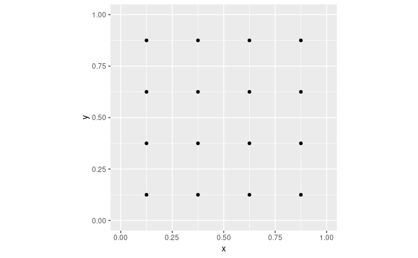

```r
ggplot(data.frame(x = anchor_xs, y = anchor_ys), aes(x, y)) +
  geom_point() +
  coord_cartesian(xlim = c(0,1), ylim = c(1,0)) +
  theme(aspect.ratio = 1)
```

In subsequent manipulations, we sometimes need center coordinates combined with height and width, and sometimes we need the corners (top-left, top-right, bottom-right, bottom-left) of the grid cells (anchor boxes).

We thus compute all of these representations and store them.

Here’s the centers + height/width representation:

```r
anchor_centers <- cbind(anchor_xs, anchor_ys)
anchor_height_width <- matrix(1 / cells_per_row, nrow = 16, ncol = 2)

anchors <- cbind(anchor_centers, anchor_height_width)
anchors
```

```
      anchor_xs anchor_ys
 [1,]     0.125     0.125 0.25 0.25
 [2,]     0.125     0.375 0.25 0.25
 [3,]     0.125     0.625 0.25 0.25
 [4,]     0.125     0.875 0.25 0.25
 [5,]     0.375     0.125 0.25 0.25
 [6,]     0.375     0.375 0.25 0.25
 [7,]     0.375     0.625 0.25 0.25
 [8,]     0.375     0.875 0.25 0.25
 [9,]     0.625     0.125 0.25 0.25
[10,]     0.625     0.375 0.25 0.25
[11,]     0.625     0.625 0.25 0.25
[12,]     0.625     0.875 0.25 0.25
[13,]     0.875     0.125 0.25 0.25
[14,]     0.875     0.375 0.25 0.25
[15,]     0.875     0.625 0.25 0.25
[16,]     0.875     0.875 0.25 0.25
```

And here’s the representation storing corners.

```r
hw2corners <- function(centers, height_width) {
  cbind(centers - height_width / 2, centers + height_width / 2) %>% unname()
}

# cells are indicated by (xl, yt, xr, yb)
# successive rows first go down in the image, then to the right
anchor_corners <- hw2corners(anchor_centers, anchor_height_width)
anchor_corners
```

```
      [,1] [,2] [,3] [,4]
 [1,] 0.00 0.00 0.25 0.25
 [2,] 0.00 0.25 0.25 0.50
 [3,] 0.00 0.50 0.25 0.75
 [4,] 0.00 0.75 0.25 1.00
 [5,] 0.25 0.00 0.50 0.25
 [6,] 0.25 0.25 0.50 0.50
 [7,] 0.25 0.50 0.50 0.75
 [8,] 0.25 0.75 0.50 1.00
 [9,] 0.50 0.00 0.75 0.25
[10,] 0.50 0.25 0.75 0.50
[11,] 0.50 0.50 0.75 0.75
[12,] 0.50 0.75 0.75 1.00
[13,] 0.75 0.00 1.00 0.25
[14,] 0.75 0.25 1.00 0.50
[15,] 0.75 0.50 1.00 0.75
[16,] 0.75 0.75 1.00 1.00
```

Let’s take our sample image again and plot it, this time including the anchor boxes / grid cells. Note that we display the scaled image now - the way the network is going to see it.

```r
example <- imageinfo4ssd[5, ]
name <- (example$name %>% str_split(pattern = ", "))[[1]]
x_left <- (example$xl %>% str_split(pattern = ", "))[[1]]
x_right <- (example$xr %>% str_split(pattern = ", "))[[1]]
y_top <- (example$yt %>% str_split(pattern = ", "))[[1]]
y_bottom <- (example$yb %>% str_split(pattern = ", "))[[1]]


img <- image_read(file.path(img_dir, example$file_name))
img <- image_resize(img, geometry = "224x224!")
img <- image_draw(img)

for (i in 1:example$cnt) {
  rect(x_left[i],
       y_bottom[i],
       x_right[i],
       y_top[i],
       border = "white",
       lwd = 2)
  text(
    x = as.integer(x_right[i]),
    y = as.integer(y_top[i]),
    labels = name[i],
    offset = 0,
    pos = 2,
    cex = 1,
    col = "white"
  )
}
for (i in 1:nrow(anchor_corners)) {
  rect(
    anchor_corners[i, 1] * 224,
    anchor_corners[i, 4] * 224,
    anchor_corners[i, 3] * 224,
    anchor_corners[i, 2] * 224,
    border = "cyan",
    lwd = 1,
    lty = 3
  )
}

dev.off()
```

```r
print(img)
```

| format | width | height | colorspace | matte | filesize | density |
| --- | --- | --- | --- | --- | --- | --- |
| JPEG | 224 | 224 | sRGB | TRUE | 0 | 72x72 |

```r
NA
```

Now it’s time to address the possibly greatest mystery when you’re new to object detection: How do you actually construct the ground truth input to the network?

That is the so-called “matching problem”.

# Matching problem

To train the network, we need to assign the ground truth boxes to the grid cells/anchor boxes.

Assume we’ve already computed the Jaccard index (= IoU) for all ground truth box - grid cell combinations. We then use the following algorithm:

1. For each ground truth object, find the grid cell it maximally overlaps with.
2. For each grid cell, find the object it overlaps with most.
3. In both cases, identify the *entity* of greatest overlap as well as the *amount* of overlap.
4. When criterium (1) applies, it overrides criterium (2).
5. When criterium (1) applies, set the amount overlap to a constant, high value: 1.99.
6. Return the combined result, that is, for each grid cell, the object and amount of best (as per the above criteria) overlap.

```r
# overlaps shape is: number of ground truth objects * number of grid cells
map_to_ground_truth <- function(overlaps) {

  # for each ground truth object, find maximally overlapping cell (crit. 1)
  # measure of overlap, shape: number of ground truth objects
  prior_overlap <- apply(overlaps, 1, max)
  # which cell is this, for each object
  prior_idx <- apply(overlaps, 1, which.max)

  # for each grid cell, what object does it overlap with most (crit. 2)
  # measure of overlap, shape: number of grid cells
  gt_overlap <-  apply(overlaps, 2, max)
  # which object is this, for each cell
  gt_idx <- apply(overlaps, 2, which.max)

  # set all definitely overlapping cells to respective object (crit. 1)
  gt_overlap[prior_idx] <- 1.99

  # now still set all others to best match by crit. 2
  # actually it's other way round, we start from (2) and overwrite with (1)
  for (i in 1:length(prior_idx)) {
    # iterate over all cells "absolutely assigned"
    p <- prior_idx[i] # get respective grid cell
    gt_idx[p] <- i # assign this cell the object number
  }

  # return: for each grid cell, object it overlaps with most + measure of overlap
  list(gt_overlap, gt_idx)

}
```

Now here’s the IoU calculation we need for that. We can’t just use our previous IoU function because this time, we want to compute overlaps with all grid cells simultaneously. It’s easiest to do this using tensors, so we temporarily convert the R matrices to tensors:

```r
# compute IOU
jaccard <- function(bbox, anchor_corners) {
  bbox <- k_constant(bbox)
  anchor_corners <- k_constant(anchor_corners)
  intersection <- intersect(bbox, anchor_corners)
  union <-
    k_expand_dims(box_area(bbox), axis = 2)  + k_expand_dims(box_area(anchor_corners), axis = 1) - intersection
    res <- intersection / union
  res %>% k_eval()
}

# compute intersection for IOU
intersect <- function(box1, box2) {
  box1_a <- box1[, 3:4] %>% k_expand_dims(axis = 2)
  box2_a <- box2[, 3:4] %>% k_expand_dims(axis = 1)
  max_xy <- k_minimum(box1_a, box2_a)

  box1_b <- box1[, 1:2] %>% k_expand_dims(axis = 2)
  box2_b <- box2[, 1:2] %>% k_expand_dims(axis = 1)
  min_xy <- k_maximum(box1_b, box2_b)

  intersection <- k_clip(max_xy - min_xy, min = 0, max = Inf)
  intersection[, , 1] * intersection[, , 2]

}

box_area <- function(box) {
  (box[, 3] - box[, 1]) * (box[, 4] - box[, 2])
}
```

# Data generator

Now, all this logic has to happen when we create the input and target data,- thus, in the data generator.

The generator has the now familiar structure, but performs some more actions.

We’ll talk through them after listing the complete code.

```r
batch_size <- 8
image_size <- target_width # same as height

threshold <- 0.4

class_background <- 21

ssd_generator <-
  function(data,
           target_height,
           target_width,
           shuffle,
           batch_size) {
    i <- 1
    function() {
      if (shuffle) {
        indices <- sample(1:nrow(data), size = batch_size)
      } else {
        if (i + batch_size >= nrow(data))
          i <<- 1
        indices <- c(i:min(i + batch_size - 1, nrow(data)))
        i <<- i + length(indices)
      }

      x <-
        array(0, dim = c(length(indices), target_height, target_width, 3))
      y1 <- array(0, dim = c(length(indices), 16))
      y2 <- array(0, dim = c(length(indices), 16, 4))

      for (j in 1:length(indices)) {
        x[j, , , ] <-
          load_and_preprocess_image(data[[indices[j], "file_name"]], target_height, target_width)

        class_string <- data[indices[j], ]$categories
        xl_string <- data[indices[j], ]$xl
        yt_string <- data[indices[j], ]$yt
        xr_string <- data[indices[j], ]$xr
        yb_string <- data[indices[j], ]$yb

        classes <-  str_split(class_string, pattern = ", ")[[1]]
        xl <-
          str_split(xl_string, pattern = ", ")[[1]] %>% as.double() %>% `/`(image_size)
        yt <-
          str_split(yt_string, pattern = ", ")[[1]] %>% as.double() %>% `/`(image_size)
        xr <-
          str_split(xr_string, pattern = ", ")[[1]] %>% as.double() %>% `/`(image_size)
        yb <-
          str_split(yb_string, pattern = ", ")[[1]] %>% as.double() %>% `/`(image_size)

        # rows are objects, columns are coordinates (xl, yt, xr, yb)
        # anchor_corners are 16 rows with corresponding coordinates
        bbox <- cbind(xl, yt, xr, yb)
        overlaps <- jaccard(bbox, anchor_corners)

        c(gt_overlap, gt_idx) %<-% map_to_ground_truth(overlaps)
        gt_class <- classes[gt_idx]

        pos <- gt_overlap > threshold
        gt_class[gt_overlap < threshold] <- 21

        # columns correspond to objects
        boxes <- rbind(xl, yt, xr, yb)
        # columns correspond to object boxes according to gt_idx
        gt_bbox <- boxes[, gt_idx]
        # set those with non-sufficient overlap to 0
        gt_bbox[, !pos] <- 0
        gt_bbox <- gt_bbox %>% t()

        y1[j, ] <- as.integer(gt_class) - 1
        y2[j, , ] <- gt_bbox

      }

      x <- x %>% imagenet_preprocess_input()
      y1 <- y1 %>% to_categorical(num_classes = class_background)
      list(x, list(y1, y2))
    }
  }
```

Before the generator can trigger any calculations, it needs to first split apart the multiple classes and bounding box coordinates.

We copy out code step-by-step from the generator so results can actually be displayed for inspection.

```r
data <- imageinfo4ssd
indices <- 1:8

j <- 5 # this is our image

class_string <- data[indices[j], ]$categories
xl_string <- data[indices[j], ]$xl
yt_string <- data[indices[j], ]$yt
xr_string <- data[indices[j], ]$xr
yb_string <- data[indices[j], ]$yb

classes <-  str_split(class_string, pattern = ", ")[[1]]
xl <- str_split(xl_string, pattern = ", ")[[1]] %>% as.double() %>% `/`(image_size)
yt <- str_split(yt_string, pattern = ", ")[[1]] %>% as.double() %>% `/`(image_size)
xr <- str_split(xr_string, pattern = ", ")[[1]] %>% as.double() %>% `/`(image_size)
yb <- str_split(yb_string, pattern = ", ")[[1]] %>% as.double() %>% `/`(image_size)
```

So here are that image’s `classes`:

```r
classes
```

```
[1] "1"  "1"  "15" "15"
```

And its left bounding box coordinates:

```r
xl
```

```
[1] 0.20535714 0.26339286 0.38839286 0.04910714
```

Now we can `cbind` those vectors to obtain a object (`bbox`) where rows are objects, and coordinates are in the columns:

```r
# rows are objects, columns are coordinates (xl, yt, xr, yb)
bbox <- cbind(xl, yt, xr, yb)
bbox
```

```
             xl        yt         xr        yb
[1,] 0.20535714 0.2723214 0.75000000 0.6473214
[2,] 0.26339286 0.3080357 0.39285714 0.4330357
[3,] 0.38839286 0.6383929 0.42410714 0.8125000
[4,] 0.04910714 0.6696429 0.08482143 0.8437500
```

So we’re ready to compute these boxes’ overlap with all of the 16 grid cells. Recall that `anchor_corners` stores the grid cells in an analogous way, the cells being in the rows and the coordinates in the columns.

```r
# anchor_corners are 16 rows with corresponding coordinates
overlaps <- jaccard(bbox, anchor_corners)
overlaps
```

```
     [,1]       [,2]       [,3]       [,4] [,5]      [,6]       [,7]       [,8] [,9]     [,10]
[1,]    0 0.03961473 0.02527960 0.00000000    0 0.2712766 0.16019417 0.00000000    0 0.2712766
[2,]    0 0.00000000 0.00000000 0.00000000    0 0.2589285 0.00000000 0.00000000    0 0.0000000
[3,]    0 0.00000000 0.00000000 0.00000000    0 0.0000000 0.06157632 0.03357313    0 0.0000000
[4,]    0 0.00000000 0.04358353 0.05121951    0 0.0000000 0.00000000 0.00000000    0 0.0000000
         [,11] [,12] [,13] [,14] [,15] [,16]
[1,] 0.1601942     0     0     0     0     0
[2,] 0.0000000     0     0     0     0     0
[3,] 0.0000000     0     0     0     0     0
[4,] 0.0000000     0     0     0     0     0
```

Now that we have the overlaps, we can call the matching logic:

```r
c(gt_overlap, gt_idx) %<-% map_to_ground_truth(overlaps)
gt_overlap
```

```
 [1] 0.00000000 0.03961473 0.04358353 1.99000000 0.00000000 1.99000000 1.99000000 0.03357313
 [9] 0.00000000 0.27127662 0.16019417 0.00000000 0.00000000 0.00000000 0.00000000 0.00000000
```

Looking for the value `1.99` in the above - the value indicating maximal, by the above criteria, overlap of an object with a grid cell - we see that boxes 4 (counting in column-major order here like R does) got matched (to a person, as we’ll see soon), the sixth did (to an airplane), and the seventh did (to a person). How about the other airplane? It got lost in the matching.

This is not a problem of the matching algorithm though - it would disappear if we had more than one anchor box per grid cell.

Looking for the objects we just mentioned in the class index, `gt_idx`, we see that indeed box 4 got matched to object 4 (a person), box 6 got matched to object 2 (an airplane), and box 7 got matched to object 3 (the other person):

```r
gt_idx
```

```
 [1] 1 1 4 4 1 2 3 3 1 1 1 1 1 1 1 1
```

By the way, don’t worry about the abundance of `1`s here. These are remnants from using `which.max` to determine maximal overlap, and will disappear soon.

Instead of thinking in object numbers, we should think in object classes (the numerical codes that is).

```r
gt_class <- classes[gt_idx]
gt_class
```

```
 [1] "1"  "1"  "15" "15" "1"  "1"  "15" "15" "1"  "1"  "1"  "1"  "1"  "1"  "1"  "1"
```

So far, we count as overlap even the very slightest overlap - of 0.1 percent even, say. Of course, this makes no sense. We set all cells with an overlap < 0.4 to the background class:

```r
 pos <- gt_overlap > threshold
gt_class[gt_overlap < threshold] <- 21

gt_class
```

```
 [1] "21" "21" "21" "15" "21" "1"  "15" "21" "21" "21" "21" "21" "21" "21" "21" "21"
```

Now, to construct the targets for learning, we need to put the bounding boxes for the objects that were found present in a cell into a matrix matching boxes to cells.

The following gives us a 16x4 matrix of cells and the boxes they are responsible for:

```r
orig_boxes <- rbind(xl, yt, xr, yb)
# columns correspond to object boxes according to gt_idx
gt_bbox <- boxes[, gt_idx]
# set those with non-sufficient overlap to 0
gt_bbox[, !pos] <- 0
gt_bbox <- gt_bbox %>% t()

gt_bbox
```

```
              xl        yt         xr        yb
 [1,] 0.00000000 0.0000000 0.00000000 0.0000000
 [2,] 0.00000000 0.0000000 0.00000000 0.0000000
 [3,] 0.00000000 0.0000000 0.00000000 0.0000000
 [4,] 0.04910714 0.6696429 0.08482143 0.8437500
 [5,] 0.00000000 0.0000000 0.00000000 0.0000000
 [6,] 0.26339286 0.3080357 0.39285714 0.4330357
 [7,] 0.38839286 0.6383929 0.42410714 0.8125000
 [8,] 0.00000000 0.0000000 0.00000000 0.0000000
 [9,] 0.00000000 0.0000000 0.00000000 0.0000000
[10,] 0.00000000 0.0000000 0.00000000 0.0000000
[11,] 0.00000000 0.0000000 0.00000000 0.0000000
[12,] 0.00000000 0.0000000 0.00000000 0.0000000
[13,] 0.00000000 0.0000000 0.00000000 0.0000000
[14,] 0.00000000 0.0000000 0.00000000 0.0000000
[15,] 0.00000000 0.0000000 0.00000000 0.0000000
[16,] 0.00000000 0.0000000 0.00000000 0.0000000
```

It is `gt_bbox`, together with `gt_class`, that we’ll return as targets for the net.

```r
y1[j, ] <- as.integer(gt_class) - 1
y2[j, , ] <- gt_bbox
```

To summarize, our target is a list of two outputs, the bounding box ground truth of dimensions *number of grid cells* times *number of box coordinates (4)*, and the class ground truth of size *number of grid cells* times *number of classes*.

We can verify this by asking the generator for a batch of inputs and targets:

```r
train_gen <- ssd_generator(
  imageinfo4ssd,
  target_height = target_height,
  target_width = target_width,
  shuffle = TRUE,
  batch_size = batch_size
)

batch <- train_gen()
c(x, c(y1, y2)) %<-% batch
dim(y1)
```

```
[1]  8 16 21
```

```r
dim(y2)
```

```
[1]  8 16  4
```

# A second look at the model

Now that we’ve seen the targets, let’s take a second look at the bounding box output of the model. Here it is again.

In the `layer_lambda`, we start from the actual anchor box centers, and move them around by a scaled-down version of the activations. We then convert these to anchor corners (same as we did above with the ground truth anchors, just operating on tensors this time).

```r
bbox_output <-
  layer_conv_2d(
    common,
    filters = 4,
    kernel_size = 3,
    padding = "same",
    name = "bbox_conv"
  ) %>%
  layer_reshape(target_shape = c(16, 4), name = "bbox_flatten") %>%
  layer_activation("tanh") %>%
  layer_permute(dims = c(2,1,3)) %>%
  layer_lambda(
    f = function(x) {
      activation_centers <-
        (x[, , 1:2] / 2 * gridsize) + k_constant(anchors[, 1:2])
      activation_height_width <-
        (x[, , 3:4] / 2 + 1) * k_constant(anchors[, 3:4])
      activation_corners <-
        k_concatenate(
          list(
            activation_centers - activation_height_width / 2,
            activation_centers + activation_height_width / 2
          )
        )
     activation_corners
    }
  )
```

```r
bbox_output <-
  layer_conv_2d(
    common,
    filters = 4,
    kernel_size = 3,
    padding = "same",
    name = "bbox_conv"
  ) %>%
  layer_reshape(target_shape = c(16, 4), name = "bbox_flatten") %>%
  layer_activation("tanh") %>%
  layer_lambda(
    f = function(x) {
      activation_centers <-
        (x[, , 1:2] / 2 * gridsize) + anchors_tf[, 1:2]
      activation_height_width <-
        (x[, , 3:4] / 2 + 1) * anchors_tf[, 3:4]
      # then convert to corners
      activation_corners <-
        k_concatenate(
          list(
            activation_centers - activation_height_width / 2,
            activation_centers + activation_height_width / 2
          )
        )
     activation_corners
    }
  )
```

```
Error in py_call_impl(callable, dots$args, dots$keywords) :
  RuntimeError: Evaluation error: object 'gridsize' not found.
```

The last ingredient missing is the loss function.